# correlacoes

Hector Medeiros

22 de abril de 2019

```r
atividade = read_projectdata()


validos = atividade %>%
          filter(!is.na(twitter),
                 !is.na(segue),
                 !is.na(seguidores))
```

# Existe correlação entre a quantidade de seguidores e o engajamento total dos parlamentares ?

Consideraremos nesta análise se existe correlação entre as variáveis número de seguidores e engajamento total dos congressistas. Como já fora discutido em questões passadas é sabido que os números diferem muito de um parlamentar para outros em números de seguidores e engajamento. Então ignorando a discrepância entre os pontos, podemos perceber que a correlação levando a escala linear tem a seguinte distruibuição.

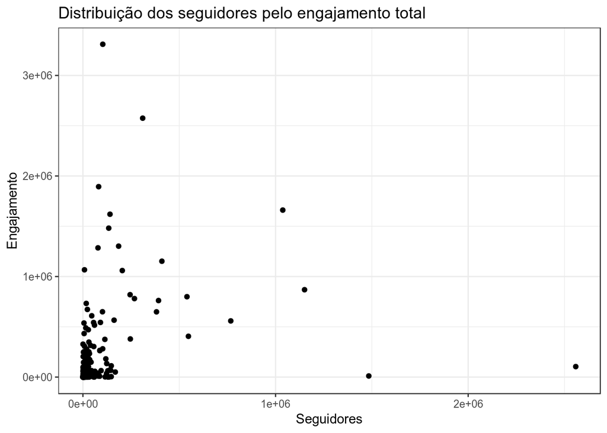

```r
validos %>%
   ggplot(aes(x = seguidores, y = engaj_total)) +
  geom_point() +
  labs(title = "Distribuição dos seguidores pelo engajamento total",
             y = "Engajamento", x = "Seguidores")
```

Considerando a distribuição utilizando uma escala com log

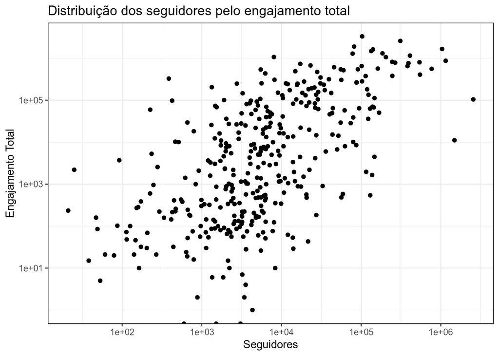

```r
validos %>%
   ggplot(aes(x = seguidores, y = engaj_total)) +
  geom_point() +
  scale_y_log10() +
  scale_x_log10() +
  labs(title = "Distribuição dos seguidores pelo engajamento total",
             y = "Engajamento Total", x = "Seguidores")
```

Percebemos que visualmente a correlação entre os pontos é maior se considerarmos a escalar logaritmíca.

Embasando nos coeficientes de correlação linear, Pearson e Spearman, podemos perceber que as variavéis tendem a mudar juntas mas em uma taxa não constante.

```r
validos %>%
    summarise(pearson = cor(seguidores, engaj_total, method = "pearson"),
            spearman = cor(seguidores, engaj_total, method = "spearman"),
            kendall = cor(seguidores, engaj_total, method = "kendall"))
```

```
## # A tibble: 1 x 3
##   pearson spearman kendall
##     <dbl>    <dbl>   <dbl>
## 1   0.290    0.628   0.448
```

```r
validos %>%
    summarise(pearson = cor(log(seguidores), log(engaj_total), method = "pearson"),
            spearman = cor(log(seguidores), log(engaj_total), method = "spearman"),
            kendall = cor(log(seguidores), log(engaj_total), method = "kendall"))
```

```
## # A tibble: 1 x 3
##   pearson spearman kendall
##     <dbl>    <dbl>   <dbl>
## 1     NaN    0.628   0.448
```

Neste ponto percebemos como os coeficientes de Spearman e Kendall não se alteram em transformações monotónas, já que continuam com os mesmo valores utilizando log. Já nesse caso a distruibuição de Pearson não se aplica.

# A quantidade de engajamento próprio tem correlação com o número de tweets próprio ?

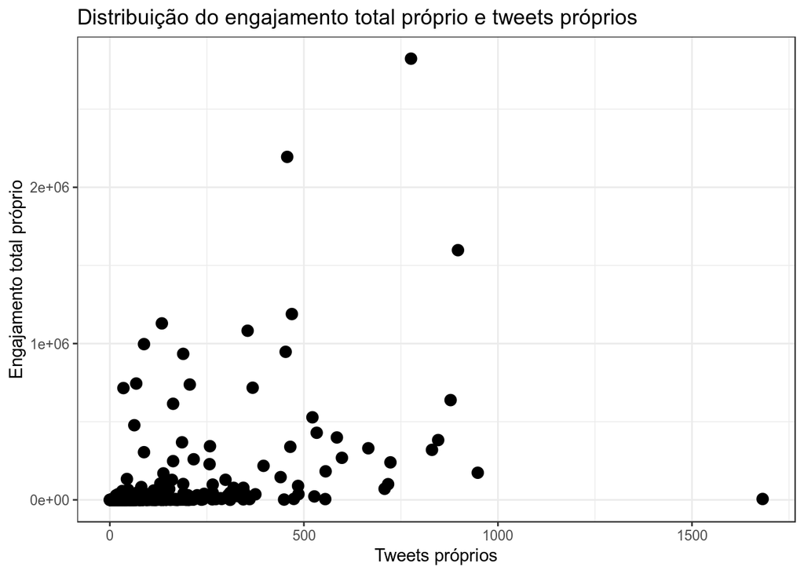

```r
validos %>%
  ggplot(aes(x = n_proprio, y = engaj_total_proprio)) +
  geom_point(size = 3, alpha = 1) +
     labs(title = "Distribuição do engajamento total próprio e tweets próprios",
             x = "Tweets próprios", y = "Engajamento total próprio")
```

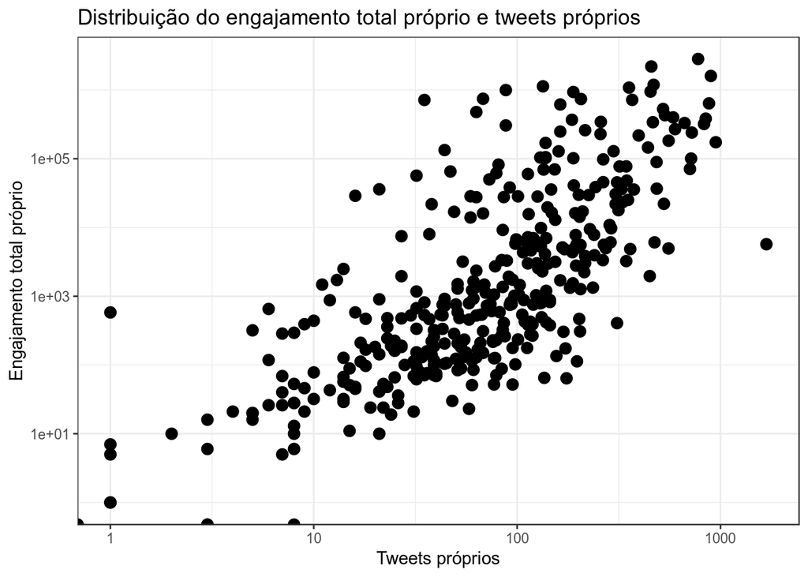

```r
validos %>%
  ggplot(aes(x = n_proprio, y = engaj_total_proprio)) +
  geom_point(size = 3, alpha = 1) +
  scale_y_log10() +
  scale_x_log10() +
     labs(title = "Distribuição do engajamento total próprio e tweets próprios",
             x = "Tweets próprios", y = "Engajamento total próprio")
```

Na primeira imagem percebe-se que a distruibuição(linear) não forma uma nuvem de pontos tão notária quanto a segunda(logarítmica). O melhor índice de correlação para indentificarmos se existe correlação ou não entre as variáveis é o coeficiente de Speraman

O correlação entre as duas variáveis é mediana, 0,74, isso significava que provavelmente a quantidade de likes e retweets muda de acordo de com a quantidade de conteúdo próprio postado, existe uma dependência razoável. Já que a mesma não é sensível a assimetria. O coeficente de Spearman para esse caso é

```r
validos %>%
    summarise(spearman = cor(n_proprio, engaj_total_proprio, method = "spearman"))
```

```
## # A tibble: 1 x 1
##   spearman
##      <dbl>
## 1    0.745
```

Então, pelo coeficiente de Spearman(0.74) que é provavél que essas essas variavéis cresçam juntas.